```python
from collections import Counter, defaultdict
from itertools import combinations
import pandas as pd
import numpy as np
import operator
import math
import itertools
from sklearn.feature_extraction import DictVectorizer
from sklearn import preprocessing, tree
import matplotlib.pyplot as plt
import seaborn as sns

!pip install keras
from keras.models import Sequential
from keras.layers import Dense, LSTM, Dropout

import tensorflow as tf
from tensorflow.keras.models import Sequential
from tensorflow.keras.layers import Dense
from tensorflow.keras.layers import LSTM

from sklearn.neural_network import MLPClassifier
from sklearn.svm import SVC

from sklearn.preprocessing import StandardScaler, MinMaxScaler
from sklearn.preprocessing import LabelEncoder, OneHotEncoder
from sklearn.feature_extraction import DictVectorizer
from sklearn.tree import DecisionTreeClassifier
from sklearn.metrics import accuracy_score, classification_report

from sklearn.pipeline import Pipeline
from sklearn.metrics import accuracy_score
from sklearn.model_selection import train_test_split
from sklearn.model_selection import GridSearchCV, ParameterGrid
from sklearn.linear_model import Ridge
from sklearn.linear_model import LinearRegression
from sklearn.metrics import mean_squared_error

from sklearn.linear_model import LinearRegression
from sklearn.neighbors import KNeighborsClassifier
from sklearn.ensemble import RandomForestClassifier
from sklearn.metrics import accuracy_score, confusion_matrix, precision_score, recall_score, ConfusionMatrixDisplay
from sklearn.model_selection import RandomizedSearchCV, train_test_split
from scipy.stats import randint

!pip install statsmodels
from statsmodels.tsa.stattools import adfuller
from statsmodels.tsa.statespace.sarimax import SARIMAX
!pip install pmdarima
from pmdarima import auto_arima

from sklearn.tree import export_graphviz
from IPython.display import Image
!pip install graphviz
import graphviz

from sklearn.metrics import mean_absolute_error, mean_squared_error
import math

np.random.seed(42)
```

[output not shown]

# Energy Capacity and Generation Gap in Indonesia

Ethan Chien, Amitesh Gargapati, Emna Sellami, Sandya Wijaya

Contributions

- Emna (~30 hours): Office Hours attendance x2, Data Collection, Classification models, Resource Allocation, Project Background, Project Objective, edited and revised Input Data Description and other cells throughout notebook.
- Amitesh (~25 hours): Data Collection, EDA, Linear & Ridge Regression, Project Objective
- Sandya (~40 hours): Office Hours attendance x3, Data Collection and Research, Helper function for preprocessing function, LSTM & ARIMAX, Helper function to print error metrics, Generating 2024 predictions for all regression models, Abstract, Limitations
- Ethan (~35 hours): Office Hours attendance x1, Data Collection, Data Cleaning, Helper function for adding target var, EDA, creating multiclass target variable, Classification models, Project Objective, Input Data Description, Generating 2024 predictions for all classification models

# Abstract

Indonesia is a diverse archipelago at the crossroads of the Pacific and Indian oceans and a key player in Southeast Asia's economic landscape. With the constant surge in population and economic activities, there is a demand for a keen assessment of energy needs -- specifically, the efficiency of energy generation.

This study's objective is to forecast electricity generation, energy capacity, and the alignment between them across Indonesian provinces. To do so, we use regression models -- Linear Regression, Ridge Regression, LSTM, and ARIMAX -- to predict energy generation & maximum capacity in 2024, then classification models -- KNN, Random Forest, and Decision Trees -- to predict whether energy is efficient in 2024. Our best regression model was Ridge Regression (RMSE of ~2000) and our best classification model was Random Forest (accuracy of ~70%). Backed by research, we defined energy generation to be 'not efficient' if it reaches 33% or below maximum capacity, 'efficient' if its between 33% and 60% efficient, and "very efficient if above 60%.

Our project is not only able to show which countries are likely to be energy production efficient in 2024, but also show how these results will differ based on which prediction method they choose. These insights will guide resource allocation in policy formulation and infrastructure development to meet the escalating energy demands in Indonesia.

# Project Background

Indonesia is a newly industrialized country between the Pacific and Indian oceans, consisting of more than 1500 islands, and one of the largest markets in Southeast Asia. As the population and economy continue to grow, that means there will be a constant and increasing demand of electricity throughout the country. While it might make sense to build more energy power plants, it is also important to look into the efficiency of the current plants to determine if and where improvements can be made.

Although Indonesia has the most developed economy in Southeast Asia, they still have transmission and distribution issues, especially in rural areas, which are further exacerbated by natural events such as earthquakes. Knowing how much energy will be generated in a province can help the government-subsidized national electricity provider “PLN” plan ahead. Further, knowing which provinces have untapped energy capacity can help identify where production can be increased without adding more plants.

Additionally, Indonesia has a lot of untapped natural resources. Developing infrastructure for solar, wind, and hydro sources can help the country scale up energy production.

# Project Objective

The main objective is to train and evaluate different models to predict electricity generation and capacity in Indonesian provinces using socioeconomic, demographic, and environmental features from 3 years prior.

To answer this question, we will break it up into three prediction questions. Firstly, we will use a given province's features (as listed above) to predict its electricity generation. The second question will be using those same factors to predict provinces' energy capacities. The last question will be a classification model: We will generate a new target variable that will split up the efficiency rates into 3 classes: 0 if efficiency is less than 0.33, 1 if efficiency is 0.33 (inclusive) and 0.6 (non-inclusive), and 2 if efficiency is 0.6 or higher. Then, we will make a classification model to predict this target variable.

After the completion of these three questions, we will divide the predicted energy generation by the predicted capacity for each province in each predicted year. We then apply our classification function to each datapoint, assigning 0s, 1s and 2s as we did in our classification model. This will allow us to directly compare the efficiency class of each province in each year based on if we performed the classification before or after modelling.

Adequate energy efficiency is a crucial component necessary to support a growing population and economy. If we can use socioeconomic, demographic, geographical, and other features to predict the energy capabilites of the future, that could help give Indonesian officials and idea of how much they need to scale up energy production.

As a result, our motivation behind our objectives is, as Indonesia currently undergoes rapid economic growth and a surge in population, the demand for electricity is increasing. We aim to address this pressing need by not only advocating for the construction of new energy power plants but also critically examining the efficiency of existing infrastructure. By conducting a detailed analysis of current power plants, we aim to identify areas for improvement to meet the country's growing energy demands sustainably.

# Input Data Description

All of the datasets we used in this project come from the BPS website, linked here: https://www.bps.go.id/id. BPS is a government agency in Indonesia that is responsible for performing and conducting statistical surveys. Because BPS is a government-run operation, they have a non-commercial goal, which is to provide data so people can track the progress of their advancement as a country. This adds to the ethos and credibility of the data.

In terms of the data on the website, we specifically looked for and used data that has granularity of both the year and the province. There are many datasets on the BPS website, but many of them are country wide data, which wasn't specific enough for what we wanted to do. We also only looked at data between the years 2011 and 2021. If we want to use socioeconomic factors to predict future electricity generation, we need to make sure our data is recent (the farther back into the past we go, the more likely the socioeconomic features will look more different than the current socioeconomic landscape of Indonesia)

We took socioeconomic, geographical, and demographic csv files from the BPS website and merged them to create our features dataframe X. For our target variables we took the energy generation and capacity csv files and attached them to rows of the feature dataframe from three years in the past so that each independent row had a future target variable. We also had to alter the capacity variable a bit by multiplying it by the number of hours in a year as well as dividing by 1000 to convert it to gigawatts, which was the unit of the energy generation target variable.

Data can be difficult to collect, especially at such a large scale as every Indonesian province; as such, there may be a buffer between when the data was actually collected and when it gets aggregated and made available to the public. The year is 2023, and the earliest data we have for the target variable is is 2021. Since this is a time-series prediction, our features need to be from the past to predict the future. These aspects of the data and modeling are the reasons why our features have to be 3 years prior to the year of the target variable.

# Data Cleaning

Because our data is from a government agency, one would think that the data is fairly clean. However, this wasn't necessarily the case. There were a few limitations of the data that we had to fix:

1. On the BPS website, for one topic or subject, the data regarding it was split up into three or four different datasets, each one containing a few years. For example, there were a total of four datasets for just the Energy Generation Dataset (one for 2021, 2018-2020, 2014-2017, and 2011-2013). Also, rather than having a column from provinces, a column for the year, and then the column for the features, it had a column for each year in the dataset. This means that for the dataset that represented 2018 to 2020, there was a column for all three years. This was inconvenient as we wanted each variable in one column rather than three split up columns.
- Solution: After discussion, we felt that it would be easier to format the data in Google Sheets rather than do many Pandas operations. Therefore, we exported all data into xlsx files and imported them into Google Sheets. Once all the data was there, we just shifted the data around until we got our preferred format, exported that as a csv, and imported it into our python notebook.
2. Because we are doing a time-series prediction with a three year look back period. Therefore, when we created a dataframe with our feature and target variables, we needed the features to be from three years before whenever the target variable came from.
- Solution: We have the province data from 2011 to 2021. Due to the three year look back period, the earliest prediction we can make is 2014, and the most recent set of features we can use is from 2018. To accomplish this, once we had all the features and target variables aggregated together, I essentially "shifted up" the target variable three years, and dropped the years 2019-2021. That way, the dataframe is able to look like how I described it. This dataframe would end up being the one we used for most of our modeling, the only time we didn't use it was when we did LSTM's, which we will describe later in this project.
3. Just like there are in many other dataset, there were some NaN values.
- Solution: We dealt with missing/NaN data using one of two ways.
  - First, our target variables (energy capacity and generation) didn't have any data from 2016, even though our socioeconomic features did. Therefore, we eliminated predicting 2016 data from our dataset (we still used 2016 features to predict 2019).
  - Second, the 'Population', 'GDP', and 'Land Area' features were missing values in the year 2011 and 2016-2021, respectively. For the 'Population' data, we found the missing values on Wikipedia, and filled in the data accordingly. For 'GDP', we also found it on Wikipedia. However, when looking at where Wikipedia got the information, it sourced back to BPS. For 'Land Area', since the land hasn't changed much in recent years between provinces, we decided to use the most recent
  - Third, there were a few sporadic NaN values. We tried to group similar NaN values together so we could come up with a generalized solution to fill them, but we ultimately decided to drop the NaN values. The idea of using regression to fill in some of the values was considered, but we didn't want to predict something using predicted values, as that would heavily increase our model variance/standard deviation. Additionally, we felt that in terms of observations, it would only be around 20 rows, so it didn't feel too bad dropping the rows with NaNs.

## Data Cleaning Code

```python
## Helper function to preprocess data from BPS
def preprocess(df, value):
    ## only want years 2011-2012
    # except for 2016
    required_columns = ['Province'] + [str(year) for year in range(2011, 2022) if (str(year) in df.columns) and year != 2016]
    filtered_df = df[required_columns]

    ## make it 1 row = 1 province at 1 year instead of 1 province
    melted_df = pd.melt(filtered_df, id_vars='Province', var_name='Year', value_name=value)

    ## making the datatype easy to work with
    # year object to datetime
    melted_df['Year'] = pd.to_datetime(melted_df['Year'], format='%Y')

    melted_df['Year'] = melted_df['Year'].apply(lambda x: x.year)

    # some rows have - as a value which cannot be converted to float, so turn to nan first
    melted_df[value] = pd.to_numeric(melted_df[value].replace('-', pd.NA), errors='coerce')

    return melted_df

## Loading in all the csv's into dataframes, and doing preprocessing
energy_generated = pd.read_csv('/work/egeneration.csv')

energy_capacity = pd.read_csv("/work/Energy Capacity.csv")
energy_capacity = preprocess(energy_capacity, 'energy_capacity')

homeowners = pd.read_csv("/work/Homeowners.csv")
homeowners.drop([35,36,37,38], inplace=True) # delete subtext
homeowners = preprocess(homeowners, 'prop_homeowners')

household_work = pd.read_csv("/work/Household working.csv")
household_work = household_work.rename(columns={'Unnamed: 0': 'Province'})
household_work = preprocess(household_work, 'prop_working')

school_inattend = pd.read_csv("/work/School Inattendance.csv")
school_inattend = preprocess(school_inattend, 'prop_school_absentees')

toilet_access = pd.read_csv("/work/Toilet Facility Access.csv")
toilet_access.drop([35,36,37,38,39], inplace=True) # delete subtext
toilet_access = preprocess(toilet_access, 'prop_toilet_access')

gdp = pd.read_csv("/work/GDP.csv")
gdp = gdp.replace(',', '', regex=True)
gdp = preprocess(gdp, 'gdp')

population = pd.read_csv("/work/Population.csv")
population = preprocess(population, 'population')

land_area = pd.read_csv("/work/Land Area.csv")
# Loop through specified columns, remove spaces
columns_to_convert = [str(year) for year in range(2011, 2022)]
for column_name in columns_to_convert:
    land_area[column_name] = land_area[column_name].str.replace(' ', '')
land_area = preprocess(land_area, 'land_area')

## putting all the loaded dataframes together
dfs_list = [energy_generated, energy_capacity, homeowners, household_work, school_inattend, toilet_access,gdp, population, land_area]  # Add all your datasets here
combined_df = pd.concat(dfs_list, axis=1)
combined_df = combined_df.loc[:, ~combined_df.columns.duplicated()]

## "Shifting up" the target variable to match up description of dataframe for time-series prediction
targets = ['energy_generated', 'energy_capacity']
drop_post_2019 = combined_df[combined_df['Year'] < 2019]
feature_df = drop_post_2019.drop(targets, axis=1)

## Helper function to shift up the data
def add_target_to_feature_df(feature_df, target_df, target_name):
    full_df = feature_df.copy()
    clean_target = target_df[target_df['Year'] >= 2014].reset_index()
    full_df[target_name] = clean_target[target_name]

    # print('num nans in target col: ' + str(clean_target[target_name].isna().sum()))

    return full_df

## Dataframe to be used for Prediction Question 1 on Energy Generation
egen_df = add_target_to_feature_df(feature_df, energy_generated, 'energy_generated')

## Dataframe to be used for Prediction Question 2 on Energy Capacity
ecap_df = add_target_to_feature_df(feature_df, energy_capacity, 'energy_capacity')
```

```python
egen_df.head(5)
```

|  | Province | Year | prop_homeowners | prop_working | prop_school_absentees | prop_toilet_access | gdp | population | land_area | energy_generated |
| --- | --- | --- | --- | --- | --- | --- | --- | --- | --- | --- |
| 0 | ACEH | 2011 | 79.02 | 87.13 | 3.17 | 60.34 | 108217.63 | 4619.0 | 57956.00 | 582.06 |
| 1 | SUMATERA UTARA | 2011 | 66.07 | 90.28 | 2.34 | 74.88 | 377037.10 | 13220.0 | 72981.23 | 18028.30 |
| 2 | SUMATERA BARAT | 2011 | 69.51 | 86.66 | 2.02 | 54.65 | 118674.29 | 4933.0 | 42012.89 | 179.47 |
| 3 | RIAU | 2011 | 68.42 | 91.90 | 2.39 | 83.81 | 485649.34 | 5726.0 | 87023.66 | 892.63 |
| 4 | JAMBI | 2011 | 78.02 | 90.87 | 3.56 | 68.12 | 103522.91 | 3168.0 | 8201.72 | 127.89 |

```python
ecap_df.head(5)
```

|  | Province | Year | prop_homeowners | prop_working | prop_school_absentees | prop_toilet_access | gdp | population | land_area | energy_capacity |
| --- | --- | --- | --- | --- | --- | --- | --- | --- | --- | --- |
| 0 | ACEH | 2011 | 79.02 | 87.13 | 3.17 | 60.34 | 108217.63 | 4619.0 | 57956.00 | 201.25 |
| 1 | SUMATERA UTARA | 2011 | 66.07 | 90.28 | 2.34 | 74.88 | 377037.10 | 13220.0 | 72981.23 | 4116.45 |
| 2 | SUMATERA BARAT | 2011 | 69.51 | 86.66 | 2.02 | 54.65 | 118674.29 | 4933.0 | 42012.89 | 72.67 |
| 3 | RIAU | 2011 | 68.42 | 91.90 | 2.39 | 83.81 | 485649.34 | 5726.0 | 87023.66 | 172.62 |
| 4 | JAMBI | 2011 | 78.02 | 90.87 | 3.56 | 68.12 | 103522.91 | 3168.0 | 8201.72 | 51.54 |

# Data Summary and Exploratory Data Analysis

The first data analysis we can look is a pairplot or a scatterplot matrix that can help us tell or identify any relationship between several pairs of variables. Looking at the various scatterplots, we can see that the relationships are varied, with some definitely not showing any correlation among each other. As scaling is also varied, we may need to individually "zoom into" the scatter plots individually to better understand the relationships. In this pairplot, from a first look at the histograms, we can see that it's clear there are some outliers.

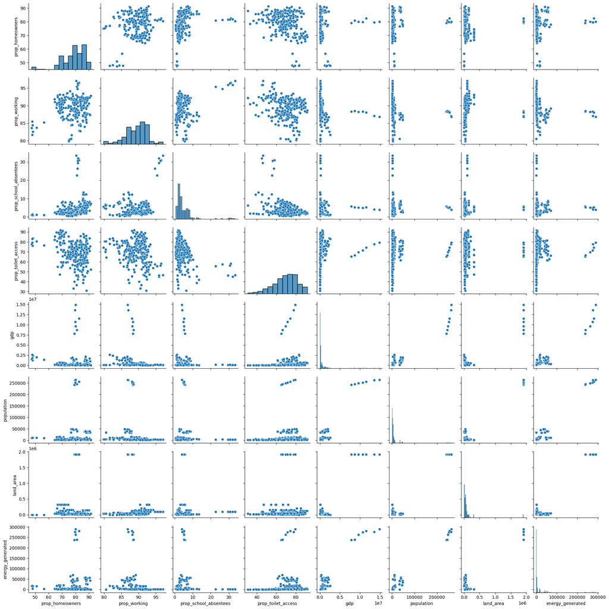

```python
import seaborn as sns
sns.pairplot(egen_df.drop('Year', axis=1))
```

Let's now look at the correlation matrix for our dataset.

```python
corr_matrix = egen_df.corr()
print(corr_matrix.index)
corr_matrix
```

```
Index(['Year', 'prop_homeowners', 'prop_working', 'prop_school_absentees',
       'prop_toilet_access', 'gdp', 'population', 'land_area',
       'energy_generated'],
      dtype='object')
```

|  | Year | prop_homeowners | prop_working | prop_school_absentees | prop_toilet_access | gdp | population | land_area | energy_generated |
| --- | --- | --- | --- | --- | --- | --- | --- | --- | --- |
| Year | 1.000000 | 0.030479 | -0.174217 | -0.113101 | 0.421871 | 0.070394 | 0.008155 | -0.002090 | 0.020647 |
| prop_homeowners | 0.030479 | 1.000000 | 0.197015 | 0.284779 | -0.334058 | -0.050321 | 0.049672 | -0.001733 | 0.050710 |
| prop_working | -0.174217 | 0.197015 | 1.000000 | 0.277504 | -0.251976 | -0.177687 | -0.157612 | -0.010123 | -0.209672 |
| prop_school_absentees | -0.113101 | 0.284779 | 0.277504 | 1.000000 | -0.349812 | -0.018016 | 0.007342 | 0.022143 | 0.004852 |
| prop_toilet_access | 0.421871 | -0.334058 | -0.251976 | -0.349812 | 1.000000 | 0.138774 | 0.087160 | 0.036332 | 0.094900 |
| gdp | 0.070394 | -0.050321 | -0.177687 | -0.018016 | 0.138774 | 1.000000 | 0.964083 | 0.918190 | 0.959129 |
| population | 0.008155 | 0.049672 | -0.157612 | 0.007342 | 0.087160 | 0.964083 | 1.000000 | 0.940830 | 0.977344 |
| land_area | -0.002090 | -0.001733 | -0.010123 | 0.022143 | 0.036332 | 0.918190 | 0.940830 | 1.000000 | 0.914000 |
| energy_generated | 0.020647 | 0.050710 | -0.209672 | 0.004852 | 0.094900 | 0.959129 | 0.977344 | 0.914000 | 1.000000 |

Converting the correlation matrix into a heat map, we are visually able to see the correlation values among each of variables in representation with the color coding. It looks like gdp, population, and land area are the variables most strongly correlated with energy generated, energy capacity, and maximum generation per province.

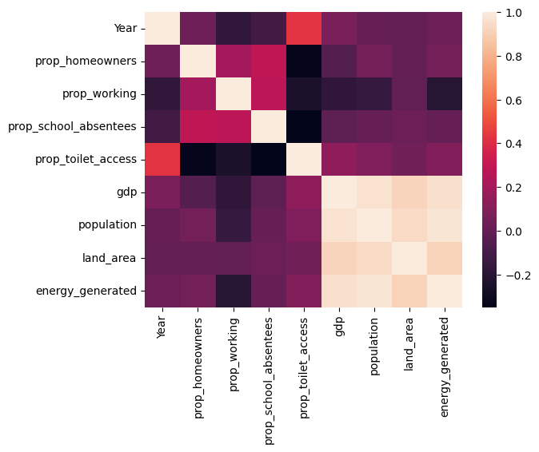

```python
sns.heatmap(corr_matrix)
```

Let's take a look at now individually the relationship between the proportion of people who are homeowners and the energy generation in a scatter plot. From the scatterplot, although we can't see a direct correlation, most of the points concentrate towards high proportion or high prop_homeowners with less than 4000 GWh.

```
(0.0, 10000.0)
```

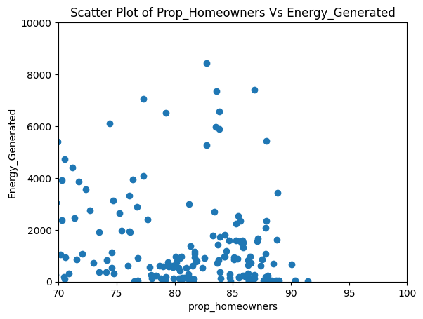

```python
plt.scatter(egen_df['prop_homeowners'], egen_df['energy_generated'])
plt.title('Scatter Plot of Prop_Homeowners Vs Energy_Generated')
plt.xlabel('prop_homeowners')
plt.ylabel('Energy_Generated')
plt.xlim(70, 100)
plt.ylim(0, 10000)
```

Finally, let's visualize the distribution of the data of energy generated across different groups of proportion of school absentees. We can do this using a violin plot. From the plot, we can see that there is some subtle correlation where there is low distribution of energy generated with low prop_school_absentees and a wider density of energy generated as prop_school_absentees increases.

[figure not shown]

```python
sns.violinplot(x='prop_school_absentees', y='energy_generated', data=egen_df)
plt.title('Violin Plot of energy_generated by _school_absentees')
plt.show()
```

# Forecasting and Prediction Modeling

## PQ1: Energy Generation [Regression]

### Models: Linear, Ridge

Before implement our modeling, here is a function we made that returns our metrics to test our models after training. so we can easily reuse for all of our models. The metrics present in our function are Mean Squared Error, Mean Absolute Error, Root Mean Squared Error, Mean Absolute Percentage Error.

```python
def print_metrics(y_true,y_pred):
    # report performance
    mse = mean_squared_error(y_true, y_pred)
    print('MSE: '+str(mse))
    mae = mean_absolute_error(y_true, y_pred)
    print('MAE: '+str(mae))
    rmse = math.sqrt(mean_squared_error(y_true, y_pred))
    print('RMSE: '+str(rmse))
    mape = np.mean(np.abs(y_pred - y_true)/np.abs(y_true))
    print('MAPE: '+str(mape))
```

Linear Regression

Before starting linear regression, we dropped the rows with NaN values of columns that had them. We split up the data into a features dataframe (X) and a target variable for energy generation (y). The data was split into a 70/30 test ratio.

```python
pq1_df = egen_df.copy().drop(['Province', 'Year'], axis=1).dropna()
X = pq1_df.drop('energy_generated', axis=1)
y = pq1_df['energy_generated']

egen_X_train, egen_X_test, egen_y_train, egen_y_test = train_test_split(X, y, test_size = 0.3, random_state = 42)

lr = LinearRegression()
lr.fit(egen_X_train, egen_y_train)
egen_y_pred = lr.predict(egen_X_test)

print_metrics(egen_y_test, egen_y_pred)
```

```
MSE: 62161635.03590299
MAE: 4781.108621527029
RMSE: 7884.265028263762
MAPE: 21.4390355073773
```

Ridge Regression

```python
from sklearn.linear_model import RidgeCV
from sklearn.model_selection import KFold

pq1_df = egen_df.copy().drop(['Province', 'Year'], axis=1).dropna()
X = pq1_df.drop('energy_generated', axis=1)
y = pq1_df['energy_generated']

egen_X_train, egen_X_test, egen_y_train, egen_y_test = train_test_split(X, y, test_size = 0.30, random_state = 42)

# Create RidgeCV model with specified alphas and use KFold cross-validation
alphas = [0.01, 0.1, 1, 10, 100, 1000, 10000]
kf = KFold(n_splits=3, shuffle=True, random_state=42)
ridge_cv = RidgeCV(cv=kf, alphas=alphas)
ridge_cv.fit(egen_X_train, egen_y_train)

ridge_alpha = ridge_cv.alpha_ # get optimal alpha value
print("optimal alpha:", ridge_alpha)

egen_y_pred = ridge_cv.predict(egen_X_test)

print_metrics(egen_y_test, egen_y_pred)
```

```
optimal alpha: 1000.0
MSE: 61476513.48026348
MAE: 4684.429659331414
RMSE: 7840.695981879637
MAPE: 21.925189597907675
```

### Findings & 2024 Prediction

As the data is setup with 3 year shift alignment, we use 2021 features data to predict the 2024 Predicted Energy Generation. Using our fitted model above, we predict the 2024 values below.

Best model: Ridge Regression

```python
# code for finding 2024 value with
find_2024 = combined_df[combined_df['Year'] ==2021].reset_index().drop(['index', 'Year','energy_capacity'], axis=1)
predicted_2024_ecap = ridge_cv.predict(find_2024.drop(['Province', 'energy_generated'],axis=1))
find_2024['2024 Predicted Energy Generation (GWh)'] = predicted_2024_ecap
rdge_predicted = find_2024[['Province', '2024 Predicted Energy Generation (GWh)']]

rdge_predicted
```

|  | Province | 2024 Predicted Energy Generation (GWh) |
| --- | --- | --- |
| 0 | ACEH | 5499.133669 |
| 1 | SUMATERA UTARA | 15512.480399 |
| 2 | SUMATERA BARAT | 4442.795738 |
| 3 | RIAU | 9231.074926 |
| 4 | JAMBI | 3472.587579 |
| 5 | SUMATERA SELATAN | 5965.574067 |
| 6 | BENGKULU | 6902.422606 |
| 7 | LAMPUNG | 4440.790434 |
| 8 | KEP. BANGKA BELITUNG | 2396.709101 |
| 9 | KEP. RIAU | 6846.920488 |
| 10 | DKI JAKARTA | 25104.101015 |
| 11 | JAWA BARAT | 52829.144980 |
| 12 | JAWA TENGAH | 20534.252067 |
| 13 | DI YOGYAKARTA | 29242.899488 |
| 14 | JAWA TIMUR | 21265.153490 |
| 15 | BANTEN | 36345.480319 |
| 16 | BALI | 4788.761933 |
| 17 | NUSA TENGGARA BARAT | 4247.203912 |
| 18 | NUSA TENGGARA TIMUR | 4338.425654 |
| 19 | KALIMANTAN BARAT | 5112.509572 |
| 20 | KALIMANTAN TENGAH | 555.307907 |
| 21 | KALIMANTAN SELATAN | 3216.780149 |
| 22 | KALIMANTAN TIMUR | 4285.083086 |
| 23 | KALIMANTAN UTARA | 1368.024170 |
| 24 | SULAWESI UTARA | 7886.473204 |
| 25 | SULAWESI TENGAH | 3160.471297 |
| 26 | SULAWESI SELATAN | 6802.482639 |
| 27 | SULAWESI TENGGARA | 4941.110877 |
| 28 | GORONTALO | 4396.553601 |
| 29 | SULAWESI BARAT | 5369.675054 |
| 30 | MALUKU | 1329.000749 |
| 31 | MALUKU UTARA | 1663.807696 |
| 32 | PAPUA BARAT | -152.643891 |
| 33 | PAPUA | 4761.740475 |
| 34 | INDONESIA | 323314.965003 |

## PQ2: Energy Capacity; Max Generation [Regression]

### Models: Linear, Ridge, LSTM, ARIMAX

To make things easier, let's first define a function that will print metrics for all our regression problems. It will output 4 different error metrics: Mean Squared Error (MSE), Mean Absolute Error (MAE), Root Mean Squared Error (RMSE), and Mean Absolute Percentage Error (MAPE). Based on a stakeholder's use case, one may prioritize a model's performance on a specific error metric which leads to different model preferences for each stakeholder.

```python
def print_metrics(y_true,y_pred):
    # report performance
    mse = mean_squared_error(y_true, y_pred)
    print('MSE: '+str(mse))
    mae = mean_absolute_error(y_true, y_pred)
    print('MAE: '+str(mae))
    rmse = math.sqrt(mean_squared_error(y_true, y_pred))
    print('RMSE: '+str(rmse))
    mape = np.mean(np.abs(y_pred - y_true)/np.abs(y_true))
    print('MAPE: '+str(mape))
```

In our case, we prioritize RMSE to understand the magnitude of errors irrespective of direction, and MAPE to show accuracy; relative error between predictions and actual values. Now that we know what error metrics we want to prioritize, let's move on to modeling!

Linear Regression

First, let's start with a simple model: Linear Regression.

```python
pq2_df = ecap_df.copy().drop(['Province', 'Year'], axis=1).dropna()
X = pq2_df.drop('energy_capacity', axis=1)
y = pq2_df['energy_capacity']

ecap_X_train, ecap_X_test, ecap_y_train, ecap_y_test = train_test_split(X, y, test_size = 0.25, random_state = 42)

lr = LinearRegression()
lr.fit(ecap_X_train, ecap_y_train)
ecap_y_pred = lr.predict(ecap_X_test)

print_metrics(ecap_y_test, ecap_y_pred)
```

```
MSE: 4028888.1622854057
MAE: 1079.511886001998
RMSE: 2007.2090479781637
MAPE: 3.818865208773382
```

Ridge Regression

```python
from sklearn.linear_model import RidgeCV
from sklearn.model_selection import KFold

pq2_df = ecap_df.copy().drop(['Province', 'Year'], axis=1).dropna()
X = pq2_df.drop('energy_capacity', axis=1)
y = pq2_df['energy_capacity']

ecap_X_train, ecap_X_test, ecap_y_train, ecap_y_test = train_test_split(X, y, test_size = 0.25, random_state = 42)


# Create RidgeCV model with specified alphas and use KFold cross-validation
alphas = [0.01, 0.1, 1, 10, 100, 1000, 10000]
kf = KFold(n_splits=3, shuffle=True, random_state=42)
ridge_cv = RidgeCV(cv=kf, alphas=alphas)
ridge_cv.fit(ecap_X_train, ecap_y_train)

ridge_alpha = ridge_cv.alpha_ # get optimal alpha value
print("optimal alpha:", ridge_alpha)

ecap_y_pred = ridge_cv.predict(ecap_X_test)


print_metrics(ecap_y_test, ecap_y_pred)
```

```
optimal alpha: 10000.0
MSE: 4029724.719327045
MAE: 1073.5428234454528
RMSE: 2007.4174252823066
MAPE: 2.9651779034030525
```

Long Short Term Memory (LSTM)

Simpler models such as linear regression and ridge regression are great for interpretability, however, they do not consider sequence dependency -- making them generally unsuitable for predictions across time (and more suited for predictions across space). Recurrent neural networks are designed to handle sequence dependence, and the Long Short-Term Memory (LSTM network) is a type of RNN used in deep learning because very large architectures can be successfully trained. Here is how it works in brief terms:

- LSTM's gates dynamically learn dependencies across sequences = allowing it to capture complex temporal patterns and long-range dependencies more effectively.
- LSTM’s memory cells preserves and process information over varying input sequences = can handle non-stationary data (data that exhibit trends and thus eligible for time series prediction)
- LSTM gates control the flow of information = allowing it to capture and update information in the memory cells based on the input and past memory content.

```python
# we just want energy capacity data
df = combined_df.drop(['energy_generated'], axis=1)
# 1) LSTMs need the input dataframe to have a granularity of 1 row = 1 year, meaning we can only choose 1 location for each model
## let's choose INDONESIA for now as it encompasses national data (all provinces)
indo_df = df[df['Province']=='INDONESIA']
indo_df
```

|  | Province | Year | energy_capacity | prop_homeowners | prop_working | prop_school_absentees | prop_toilet_access | gdp | population | land_area |
| --- | --- | --- | --- | --- | --- | --- | --- | --- | --- | --- |
| 34 | INDONESIA | 2011 | 35596.74 | 79.22 | 88.36 | 5.72 | 65.20 | 7825075.53 | 241991.0 | 1910931.32 |
| 69 | INDONESIA | 2012 | 44841.54 | 80.89 | 88.50 | 5.24 | 66.53 | 8672954.41 | 245416.0 | 1910931.32 |
| 104 | INDONESIA | 2013 | 45476.31 | 80.08 | 88.21 | 5.16 | 69.71 | 9612506.50 | 248818.0 | 1910931.32 |
| 139 | INDONESIA | 2014 | 53015.70 | 79.77 | 88.34 | 4.87 | 71.52 | 10699877.63 | 252165.0 | 1910931.32 |
| 174 | INDONESIA | 2015 | 54400.17 | 82.63 | 88.10 | 5.25 | 74.34 | 11526332.80 | 255462.0 | 1913578.68 |
| 209 | INDONESIA | 2017 | 58163.33 | 79.61 | 87.06 | 4.15 | 77.84 | 13589825.70 | 261891.0 | 1913578.68 |
| 244 | INDONESIA | 2018 | 63746.79 | 80.02 | 86.85 | 3.96 | 79.35 | 14838756.00 | 264161.6 | 1913578.68 |
| 279 | INDONESIA | 2019 | 64842.53 | 80.07 | 87.07 | 3.57 | 81.13 | 15832657.20 | 266911.9 | 1913578.68 |
| 314 | INDONESIA | 2020 | 65235.81 | 80.10 | 86.66 | 3.19 | 82.86 | 15438017.50 | 270203.9 | 1913578.68 |
| 349 | INDONESIA | 2021 | 66514.31 | 81.08 | 87.72 | 3.01 | 85.51 | 16970789.20 | 272682.5 | 1913578.68 |

```python
# 2) Normalize target variable values to improve model convergence.
from sklearn.preprocessing import MinMaxScaler
scaler = MinMaxScaler(feature_range=(0,1)) # The minmaxscaler converts values to a range (e.g., 0 to 1)
indo_df['scaled_values'] = scaler.fit_transform(indo_df['energy_capacity'].values.reshape(-1,1))
indo_df = indo_df.reset_index().drop('index',axis=1) # ensure all indexes are consecutive
indo_df
```

|  | Province | Year | energy_capacity | prop_homeowners | prop_working | prop_school_absentees | prop_toilet_access | gdp | population | land_area | scaled_values |
| --- | --- | --- | --- | --- | --- | --- | --- | --- | --- | --- | --- |
| 0 | INDONESIA | 2011 | 35596.74 | 79.22 | 88.36 | 5.72 | 65.20 | 7825075.53 | 241991.0 | 1910931.32 | 0.000000 |
| 1 | INDONESIA | 2012 | 44841.54 | 80.89 | 88.50 | 5.24 | 66.53 | 8672954.41 | 245416.0 | 1910931.32 | 0.299014 |
| 2 | INDONESIA | 2013 | 45476.31 | 80.08 | 88.21 | 5.16 | 69.71 | 9612506.50 | 248818.0 | 1910931.32 | 0.319545 |
| 3 | INDONESIA | 2014 | 53015.70 | 79.77 | 88.34 | 4.87 | 71.52 | 10699877.63 | 252165.0 | 1910931.32 | 0.563400 |
| 4 | INDONESIA | 2015 | 54400.17 | 82.63 | 88.10 | 5.25 | 74.34 | 11526332.80 | 255462.0 | 1913578.68 | 0.608179 |
| 5 | INDONESIA | 2017 | 58163.33 | 79.61 | 87.06 | 4.15 | 77.84 | 13589825.70 | 261891.0 | 1913578.68 | 0.729895 |
| 6 | INDONESIA | 2018 | 63746.79 | 80.02 | 86.85 | 3.96 | 79.35 | 14838756.00 | 264161.6 | 1913578.68 | 0.910487 |
| 7 | INDONESIA | 2019 | 64842.53 | 80.07 | 87.07 | 3.57 | 81.13 | 15832657.20 | 266911.9 | 1913578.68 | 0.945928 |
| 8 | INDONESIA | 2020 | 65235.81 | 80.10 | 86.66 | 3.19 | 82.86 | 15438017.50 | 270203.9 | 1913578.68 | 0.958648 |
| 9 | INDONESIA | 2021 | 66514.31 | 81.08 | 87.72 | 3.01 | 85.51 | 16970789.20 | 272682.5 | 1913578.68 | 1.000000 |

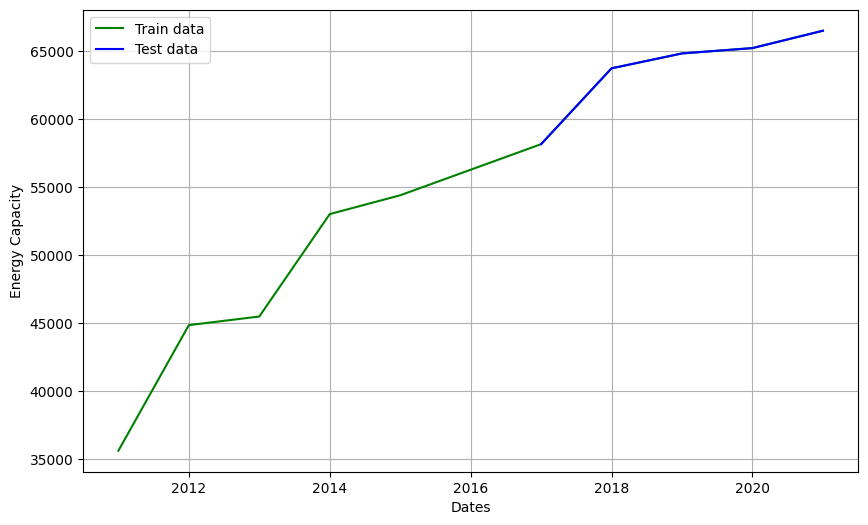

```python
# 3) Split data into train and training set
train_data = indo_df[indo_df['Year'] < 2017] # can only train using data up until 2018 because newest data is in 2021 (and our lookback is 3 years)
test_data = indo_df[indo_df['Year'] >= 2017]

# plotting the data
plt.figure(figsize=(10,6))
plt.grid(True)
plt.xlabel('Dates')
plt.ylabel('Energy Capacity')
plt.plot(indo_df['Year'], indo_df['energy_capacity'], 'green', label='Train data')
plt.plot(test_data['Year'], test_data['energy_capacity'], 'blue', label='Test data')
plt.legend()
```

```python
# 4) Now, get x train & y train from the training set
x_train = []
y_train = []

# choose 3 year as the lookback period; 2000 to predict 2003, and so on
for i in range(3, len(train_data['scaled_values'])):
    historical_values = train_data['scaled_values'][i-3:i]
    # additional features to historical data
    additional_features = ['prop_homeowners', 'prop_working', 'prop_school_absentees', 'prop_toilet_access', 'gdp', 'population', 'land_area']
    additional_feature_values = np.empty((len(historical_values), len(additional_features)))
    for idx, feature_name in enumerate(additional_features):
        # gather values for each of the features for the same lookback period
        feature_values = train_data[feature_name][i-3:i]
        additional_feature_values[:, idx] = feature_values
    # combine historical & additional features
    combined_features = np.column_stack((historical_values, additional_feature_values))
    x_train.append(combined_features)
    # Check if the index exists in 'scaled_values' before appending to y_train
    if i in train_data.index:
        y_train.append(train_data['scaled_values'][i])

x_train, y_train = np.array(x_train), np.array(y_train)

# converting it back to 3D array as required by LSTM
x_train = np.reshape(x_train, (x_train.shape[0], x_train.shape[1], x_train.shape[2]))
```

```python
# 4) Do the same thing to get x test & y test from the testing set
x_test = []
y_test = test_data['scaled_values']

for i in range(3, len(test_data['scaled_values'])):
    historical_values = test_data['scaled_values'][i-3:i]
    additional_features = ['prop_homeowners', 'prop_working', 'prop_school_absentees', 'prop_toilet_access', 'gdp', 'population', 'land_area']
    additional_feature_values = np.empty((len(historical_values), len(additional_features)))
    for idx, feature_name in enumerate(additional_features):
        # gather values for each of the features for the same lookback period
        feature_values = test_data[feature_name][i-3:i]
        additional_feature_values[:, idx] = feature_values
    # combine historical & additional features
    combined_features = np.column_stack((historical_values, additional_feature_values))
    x_test.append(combined_features)

x_test = np.array(x_test)
x_test = np.reshape(x_test, (x_test.shape[0], x_test.shape[1], x_test.shape[2]))
```

Our neural network architecture stacked

```python
# 5) Now, let's start building our LSTM model!

# Initialize model
lstm = Sequential()
# LSTM layer 1
lstm.add(LSTM(units = 50, return_sequences = True, input_shape = (x_train.shape[1], x_train.shape[2])))
lstm.add(Dropout(0.25)) # dropout layers help prevent overfitting; switches off machine randomly to prevent hyperfixing on specific details
# LSTM layer 2
lstm.add(LSTM(units = 50, return_sequences = True))
lstm.add(Dropout(0.25))
# LSTM layer 3
lstm.add(LSTM(units = 50))
lstm.add(Dropout(0.25))
# final layer
lstm.add(Dense(units = 1, activation ='linear')) # having activation function linear is suited for regression
lstm.summary()
```

```
2023-12-15 01:06:09.798171: W tensorflow/stream_executor/platform/default/dso_loader.cc:64] Could not load dynamic library 'libcuda.so.1'; dlerror: libcuda.so.1: cannot open shared object file: No such file or directory
2023-12-15 01:06:09.798214: W tensorflow/stream_executor/cuda/cuda_driver.cc:263] failed call to cuInit: UNKNOWN ERROR (303)
2023-12-15 01:06:09.798243: I tensorflow/stream_executor/cuda/cuda_diagnostics.cc:156] kernel driver does not appear to be running on this host (p-9a2d3571-826e-4759-814d-0768207fd99f): /proc/driver/nvidia/version does not exist
2023-12-15 01:06:09.798546: I tensorflow/core/platform/cpu_feature_guard.cc:193] This TensorFlow binary is optimized with oneAPI Deep Neural Network Library (oneDNN) to use the following CPU instructions in performance-critical operations:  AVX2 FMA
To enable them in other operations, rebuild TensorFlow with the appropriate compiler flags.
Model: "sequential"
_________________________________________________________________
 Layer (type)                Output Shape              Param #
=================================================================
 lstm (LSTM)                 (None, 3, 50)             11800

 dropout (Dropout)           (None, 3, 50)             0

 lstm_1 (LSTM)               (None, 3, 50)             20200

 dropout_1 (Dropout)         (None, 3, 50)             0

 lstm_2 (LSTM)               (None, 50)                20200

 dropout_2 (Dropout)         (None, 50)                0

 dense (Dense)               (None, 1)                 51

=================================================================
Total params: 52,251
Trainable params: 52,251
Non-trainable params: 0
_________________________________________________________________
```

```python
# 6) The model is trained by giving it example sequences in small batches of 32, then the machine repeats this practice 50 times before finally making a prediction
lstm.compile(optimizer='adam', loss='mean_squared_error', metrics=['accuracy'])
lstm.fit(x_train, y_train, epochs = 50, batch_size=32)
```

```
<keras.callbacks.History at 0x7f379c323650>
```

```python
# 7) Predict on test data
predicted_capacity = lstm.predict(x_test)
predicted_capacity = scaler.inverse_transform(predicted_capacity)

# We can print the error metrics as well!
y_t = test_data[3:]['energy_capacity'].values
y_p = predicted_capacity
print_metrics(y_t, y_p)
```

```
MSE: 124816861.25947183
MAE: 11153.843203124998
RMSE: 11172.146671945899
MAPE: 0.16923991836697821
```

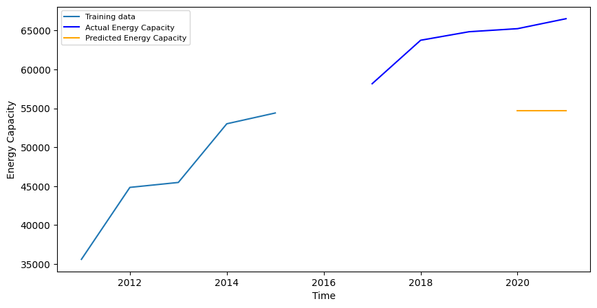

```python
# 7) For a more visual view of our prediction, we can generate a plot too!
plt.figure(figsize=(10,5), dpi=100)
plt.plot(train_data['Year'], train_data['energy_capacity'], label='Training data')
plt.plot(test_data['Year'], test_data['energy_capacity'], color = 'blue', label='Actual Energy Capacity')
plt.plot(test_data[3:]['Year'], predicted_capacity, color = 'orange',label='Predicted Energy Capacity')

plt.xlabel('Time')
plt.ylabel('Energy Capacity')
plt.legend(loc='upper left', fontsize=8)
plt.show()
```

ARIMA - Non-exogenous

Let's try another model that is suited for short-term predictions! Doing some simple searching, we noticed that a popular model is ARIMAx, which stands for the following:

- AR (AutoRegressive): captures the relationship between the current observation and its past values
- I (Integrated): involves differencing the time series to make it stationary
- MA (Moving Average): models the relationship between the current observation and a residual error from a moving average model applied to lagged observations
- X (Exogenous Variables): adds in additional correlated variables to the target goal to tune its predictions

Before we start an ARIMAx model, we must first find autocorrelation using moving average/moving STD test and Adfuller test. There are 2 primary way to determine whether a given time series is stationary.

1. Rolling Statistics: Plot the rolling mean and rolling standard deviation. The time series is stationary if they remain constant with time (with the naked eye look to see if the lines are straight and parallel to the x-axis).
2. Augmented Dickey-Fuller Test: The time series is considered stationary if the p-value is low (according to the null hypothesis) and the critical values at 1%, 5%, 10% confidence intervals are as close as possible to the ADF Statistics

```python
def get_stationarity(time_series):
    rolling_mean = time_series.rolling(window=4).mean()
    rolling_std = time_series.rolling(window=4).std()

    # rolling statistics plot
    original = plt.plot(time_series, color='blue', label='Original')
    mean = plt.plot(rolling_mean, color='red', label='Rolling Mean')
    std = plt.plot(rolling_std, color='black', label='Rolling Std')
    plt.legend(loc='best')
    plt.title('Rolling Mean & Standard Deviation')
    plt.show(block=False)

    # Dickey–Fuller test:
    result = adfuller(time_series['energy_capacity'])
    print('ADF Statistic: {}'.format(result[0]))
    print('p-value: {}'.format(result[1]))
    print('Critical Values:')
    for key, value in result[4].items():
        print('\t{}: {}'.format(key, value))
```

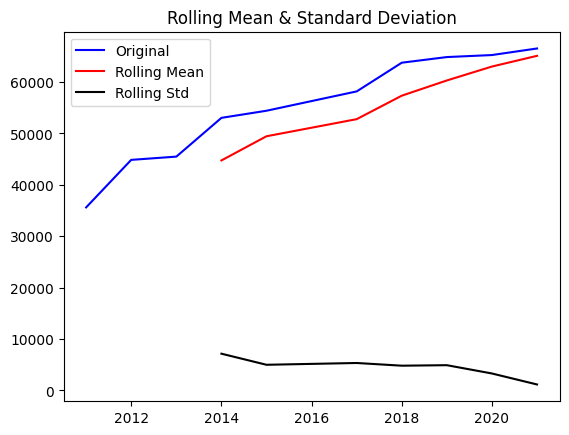

```
ADF Statistic: -2.46029648568085
p-value: 0.12543582583454183
Critical Values:
	1%: -4.473135048010974
	5%: -3.28988060356653
	10%: -2.7723823456790124
```

```python
# 1) Test stationary of energy_capacity data -- to do this, only need capacity columns
just_energy_year = indo_df[['Year','energy_capacity']]
just_energy_year.index = pd.to_datetime(just_energy_year["Year"].astype(str), format='%Y')
just_energy_year.drop('Year',axis=1,inplace=True)

get_stationarity(just_energy_year)
```

```python
# 2) Determine the order of the ARIMA model using either autoarima or correlograms such as ACF and PACF plots.

# In this case, we are just fitting an auto ARIMA model to determine the best parameters (p, d, q)
auto_arima_model = auto_arima(just_energy_year)
# Get the summary of the auto ARIMA model
print(auto_arima_model.summary())
```

```
                               SARIMAX Results
==============================================================================
Dep. Variable:                      y   No. Observations:                   10
Model:               SARIMAX(1, 0, 0)   Log Likelihood                 -99.627
Date:                Fri, 15 Dec 2023   AIC                            205.254
Time:                        01:06:18   BIC                            206.162
Sample:                             0   HQIC                           204.258
                                 - 10
Covariance Type:                  opg
==============================================================================
                 coef    std err          z      P>|z|      [0.025      0.975]
------------------------------------------------------------------------------
intercept   3430.7040   7674.421      0.447      0.655   -1.16e+04    1.85e+04
ar.L1          0.9338      0.158      5.925      0.000       0.625       1.243
sigma2      2.131e+07      3.134    6.8e+06      0.000    2.13e+07    2.13e+07
===================================================================================
Ljung-Box (L1) (Q):                   3.53   Jarque-Bera (JB):                 0.57
Prob(Q):                              0.06   Prob(JB):                         0.75
Heteroskedasticity (H):               0.10   Skew:                            -0.58
Prob(H) (two-sided):                  0.09   Kurtosis:                         3.13
===================================================================================

Warnings:
[1] Covariance matrix calculated using the outer product of gradients (complex-step).
[2] Covariance matrix is singular or near-singular, with condition number 1.03e+28. Standard errors may be unstable.
```

```python
# 3) Create train/test split so we can see how accurate our model is
tr_start,tr_end = '2011-01-01','2017-01-01'
te_start,te_end = '2018-01-01','2020-01-01'
tra = just_energy_year["energy_capacity"][tr_start:tr_end].dropna()
tes = just_energy_year["energy_capacity"][te_start:te_end].dropna()
```

[output not shown]

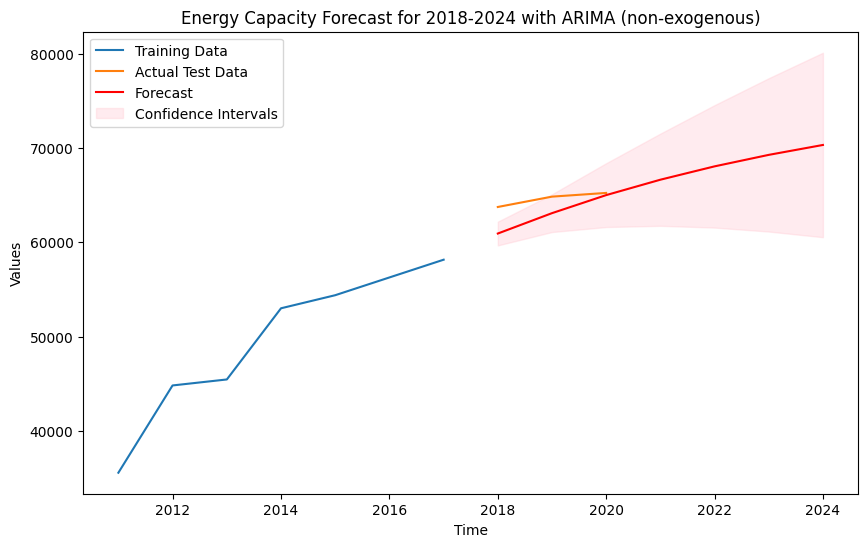

```
MSE: 3675570.282059328
MAE: 1598.4156870189738
RMSE: 1917.177686616274
MAPE: 0.02489203628114203
```

```python
# 4) Train SARIMAX model
model = SARIMAX(tra, order=(2, 1, 2), enforce_invertibility=False, enforce_stationarity=False)
results = model.fit()

# 5) Forecast!
# Generate future dates for prediction (2022-2024)
future_dates = pd.date_range(start='2018-01-01', end='2024-01-01', freq='AS')  # Adjust the date range as needed
# Forecast for defined future period
forecast = results.get_forecast(steps=len(future_dates))
# Extract forecasted values and confidence intervals
forecast_values = forecast.predicted_mean.values
confidence_intervals = forecast.conf_int()
# Create a DataFrame with forecasted values and dates as index
forecast_df = pd.DataFrame(forecast_values, index=future_dates, columns=['Forecast'])

# 6) Plotting & metrics
plt.figure(figsize=(10, 6))
plt.plot(tra.index, tra.values, label='Training Data')
plt.plot(tes.index, tes.values, label='Actual Test Data')
plt.plot(forecast_df.index, forecast_df['Forecast'], color='red', label='Forecast')

# Fill confidence intervals
plt.fill_between(
    forecast_df.index,
    confidence_intervals.iloc[:, 0],
    confidence_intervals.iloc[:, 1],
    color='pink', alpha=0.3,
    label='Confidence Intervals'
)

plt.title('Energy Capacity Forecast for 2018-2024 with ARIMA (non-exogenous)')
plt.xlabel('Time')
plt.ylabel('Values')
plt.legend(loc='upper left')
plt.show()

print_metrics(tes.values, forecast.predicted_mean.values[:3])
```